# Prediction Assignment for Practicle Machine Learning Class

Mitta Suresh

Thursday, June 18, 2015

## Executive Summary:

Few machinlearning algorithm was applied to the given data to come up with prediction model. The best one is adopted as the final solution. The training data set provided was explored and refined before applying the machine learning algoritms. Based on project background it is evident that linear models don’t work well for this type of problems. Cluster algorithms would work the best. In my case Random Forest provided the best results. The out of bag error rate for the final model is 1.68%. Additionally when a test was run on the validation data it showed an accuracy of 99%.

## Data Clean up and Tidy Data:

The training data had 159 predictor variables. Some of them were wrongly classified as factor variables when they should be numeric. I also noted that the very first one was just a straight index of row numbers (which will add nothing meaningful to the analysis). In addition vast number of predictor variables had very little data, over 90% of the values in this group were NAs. A robust Model cannot be developed with predictors with mostly missing data, consequently they should be removed from analysis (this is similar to nzv, near zero variables).

```r
# Load Data files
testing=read.csv("C:/Users/Suresh/Documents/r/data/pml-testing.csv")
training=read.csv("C:/Users/Suresh/Documents/r/data/pml-training.csv")
library(caret)
```

Following steps were taken to clean up:  
1. Convert factor variables to numeric for certain columns  
2. Identify all variables with over 90% NAs  
3. Reduce the number of variables for analysis

```r
# Convert some wrongly labelled factor variables to numeric class, Identified list is saved as an a
load("C:/Users/Suresh/Documents/r/data/convertCols.rda")
for (i in 1:length(convertCols)){
        training[,convertCols[i]]=as.numeric(as.character(training[,convertCols[i]]))
}
# Identify all the columns which have excessive missing data
naCols=NULL
for (i in 1:ncol(training)){
        if (sum(is.na(training[,i])) > 0.9*nrow(training)) {naCols=c(naCols,i)}
}
#remove mostly NA columnar data and col1 which is just a serial number
newtrain=training[,-c(1,naCols)]
# split the traing data for model creation and validation
inTrain=createDataPartition(y=newtrain$classe,p=0.6,list=F)
nttrain=newtrain[inTrain,]
nttest=newtrain[-inTrain,]
```

## Expolatory Data Analysis

Due to the large number of predictor variables and also large number of rows which ends up taking lot of processing time. I choose to explore the running models on a sub set of data. I chose 10% of data (playtrain) to understand the general model fits to speed up the process.

```r
# select small slice of data to play around
set.seed(1000)
inTrain=createDataPartition(y=newtrain$classe,p=0.1,list=FALSE)
playtrain=newtrain[inTrain,]
inTest=createDataPartition(y=newtrain$classe,p=0.1,list=FALSE)
playtest=newtrain[inTest,]
```

I ran various models to fit as part of exploratory analysis. They included classification trees, bagging, boosting, Naive Bayes and Random Forest. The accuract I got was 48.8%, 71%,93%, 69.3% and 98.5% respectively. As sample of a dendogram generated from one the analysis is presented here.

[figure not shown]

```r
playfitRF=train(classe~.,method="rf",data=playtrain)
save(playfitRF,file="playfitRF.rda")
```

```r
# to avoid time loading the model that was previously created
load("C:/Users/Suresh/Documents/r/data/playfitRF.rda")
varImp(playfitRF)
```

```
## rf variable importance
##
##   only 20 most important variables shown (out of 79)
##
##                                Overall
## raw_timestamp_part_1           100.000
## roll_belt                       56.615
## num_window                      38.824
## pitch_forearm                   37.930
## magnet_dumbbell_y               32.510
## magnet_dumbbell_z               28.275
## yaw_belt                        19.996
## pitch_belt                      18.298
## cvtd_timestamp02/12/2011 13:33  16.108
## roll_dumbbell                   12.903
## magnet_dumbbell_x               12.595
## accel_belt_z                    11.749
## cvtd_timestamp30/11/2011 17:12  10.039
## roll_forearm                     9.949
## magnet_belt_y                    9.794
## cvtd_timestamp28/11/2011 14:13   9.606
## accel_dumbbell_y                 8.471
## cvtd_timestamp02/12/2011 14:58   8.427
## accel_forearm_x                  7.815
## magnet_belt_z                    6.841
```

Following the analysis of the variables from varImp function. 10 Predictors were selected. Pairs plot of these variables are plotted.

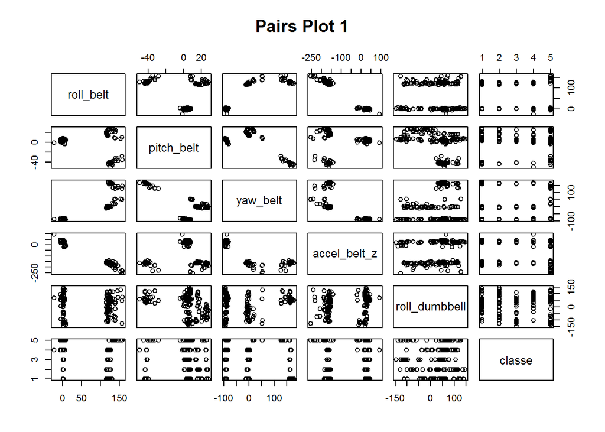

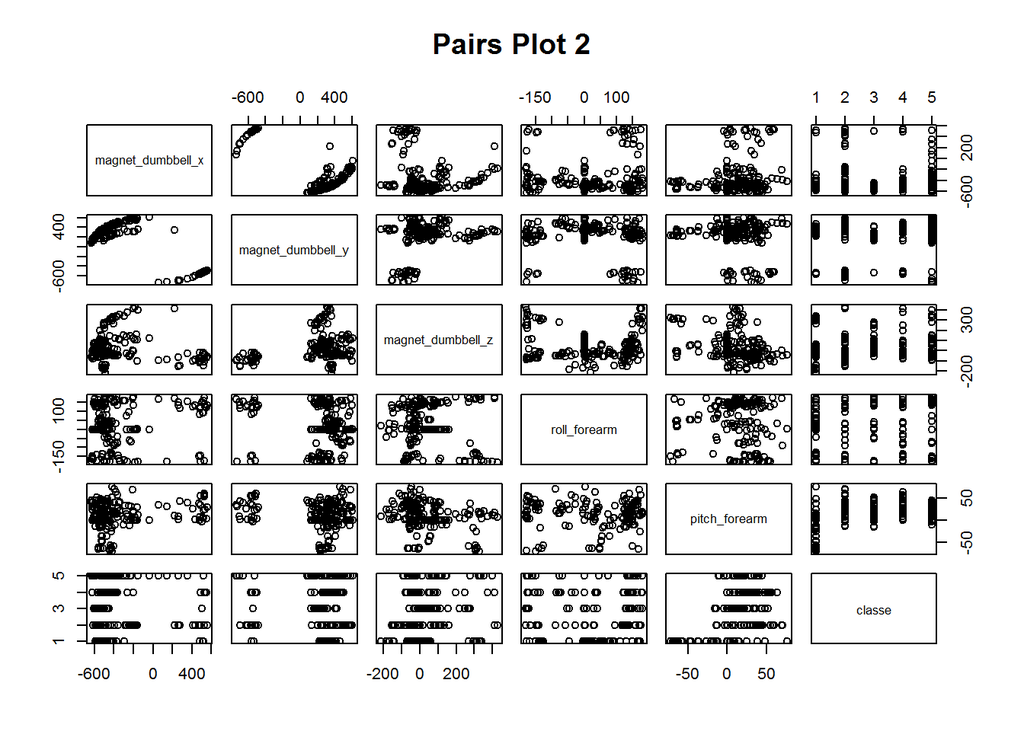

## Final Model Fitting

Based on exploratory data analysis, a model was fit to the training (nttrain) data, using the identified variables for a rondom foreset method.

```r
fitsens10RF=train(classe~roll_belt+pitch_forearm+magnet_dumbbell_y+magnet_dumbbell_z+yaw_belt+pitch_belt+roll_dumbbell+magnet_dumbbell_x+accel_belt_z+roll_forearm,method="rf",data=nttrain)
```

[output not shown]

This resulted in a model with an out of Bag (OOB) error of 1.68%

```r
#check effectiveness of the model - Validation
confusionMatrix(nttest$classe,predict(fitsens10RF,nttest))
```

```
## Confusion Matrix and Statistics
##
##           Reference
## Prediction    A    B    C    D    E
##          A 2229    1    2    0    0
##          B    5 1497   15    1    0
##          C    0    5 1360    3    0
##          D    0    1    4 1280    1
##          E    0    4    0    3 1435
##
## Overall Statistics
##
##                Accuracy : 0.9943
##                  95% CI : (0.9923, 0.9958)
##     No Information Rate : 0.2847
##     P-Value [Acc > NIR] : < 2.2e-16
##
##                   Kappa : 0.9927
##  Mcnemar's Test P-Value : NA
##
## Statistics by Class:
##
##                      Class: A Class: B Class: C Class: D Class: E
## Sensitivity            0.9978   0.9927   0.9848   0.9946   0.9993
## Specificity            0.9995   0.9967   0.9988   0.9991   0.9989
## Pos Pred Value         0.9987   0.9862   0.9942   0.9953   0.9951
## Neg Pred Value         0.9991   0.9983   0.9968   0.9989   0.9998
## Prevalence             0.2847   0.1922   0.1760   0.1640   0.1830
## Detection Rate         0.2841   0.1908   0.1733   0.1631   0.1829
## Detection Prevalence   0.2845   0.1935   0.1744   0.1639   0.1838
## Balanced Accuracy      0.9986   0.9947   0.9918   0.9968   0.9991
```

## Conclusion

The results show that the model created with 10 predictors using random foreset is highly accurate. The Sensitivity, Specificity, PPV (Positive Predictive Value) and NPV (Negative Predictive value) are all very high. Additionallly the accuracy between classes is also well balanced indicating there is no need to adjust the weighting of any class.